# ML practice 1: classification

Сегодня мы посмотрим на результаты классификации на нескольких датасетах. Сначала перечислим датасеты, с которыми затем будем работать.

### 1. Ирисы

Популярный учебный датасет про три сорта ирисов

```r
data(iris)
```

Посмотрим на данные:

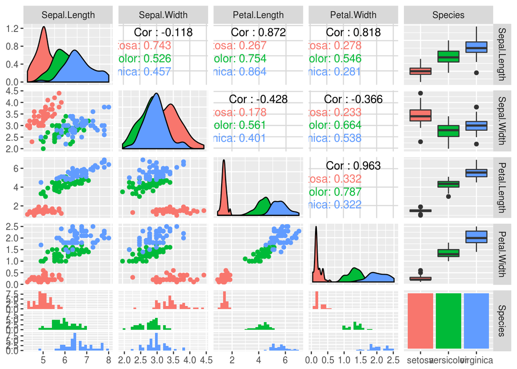

```r
library(ggplot2)
library(GGally)
ggpairs(iris, mapping = aes(color = Species))
```

### 2. Рак груди

Второй датасет, с которым мы работаем сегодня – результаты диагностики опухоли груди. Вызовите справку по датасету `?mlbench::BreastCancer`

- какой размер датасета?
- какие переменные в нем есть?

```r
library(mlbench)
data(BreastCancer)
library(dplyr)
BreastCancer = select(BreastCancer, -Id)
```

Зачем выполнена последняя операция?

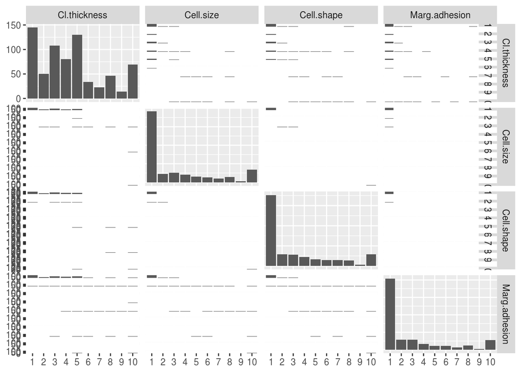

```r
ggpairs(BreastCancer, columns = c(1,2,3,4))
```

**Ваша очередь:** Постройте подобный график только для других переменных

```r
#put some code here
```

# Деревья решений: recap

Используем пакет `partykit`.

```r
library(partykit)
```

Построим дерево (ирисы)

```r
tree.iris <- ctree(Species~., data = iris)
tree.iris
```

```
##
## Model formula:
## Species ~ Sepal.Length + Sepal.Width + Petal.Length + Petal.Width
##
## Fitted party:
## [1] root
## |   [2] Petal.Length <= 1.9: setosa (n = 50, err = 0.0%)
## |   [3] Petal.Length > 1.9
## |   |   [4] Petal.Width <= 1.7
## |   |   |   [5] Petal.Length <= 4.8: versicolor (n = 46, err = 2.2%)
## |   |   |   [6] Petal.Length > 4.8: versicolor (n = 8, err = 50.0%)
## |   |   [7] Petal.Width > 1.7: virginica (n = 46, err = 2.2%)
##
## Number of inner nodes:    3
## Number of terminal nodes: 4
```

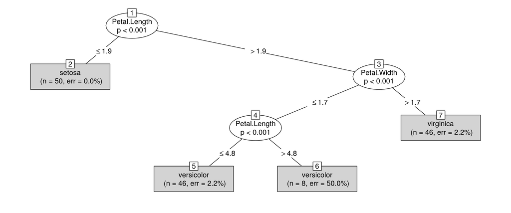

```r
plot(tree.iris, type = "simple")
```

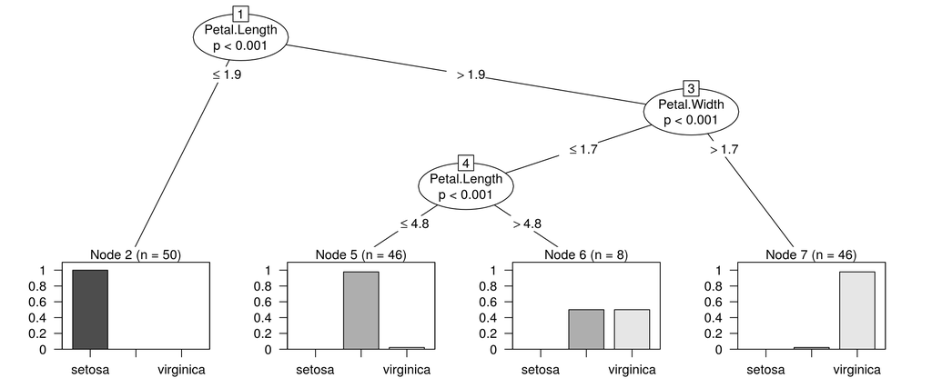

```r
plot(tree.iris)
```

- Какие “правила” получились?

Построим более сложное дерево (рак груди)

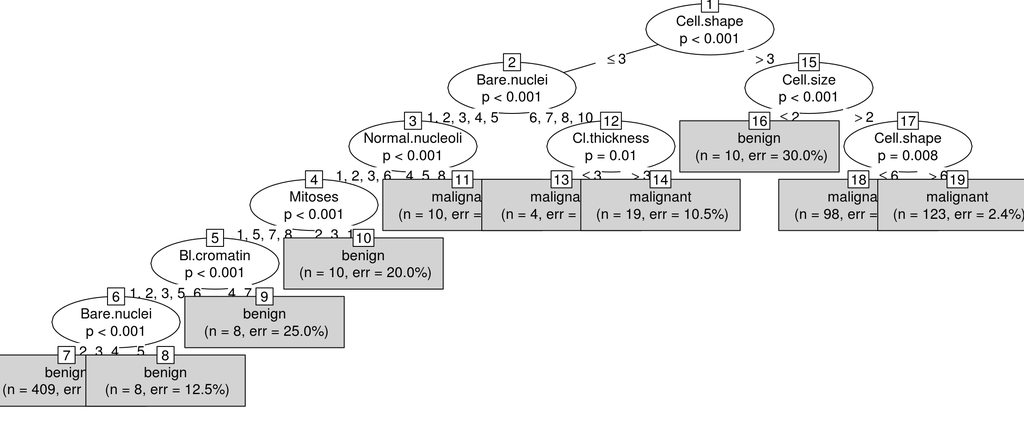

```r
tree.breast <- ctree(Class~., data = BreastCancer)
plot(tree.breast, type = "simple")
```

- Можете ли вы “прочитать” это дерево?
- Какие “правила” получились?
- Все ли переменные из данных использованы?

Но насколько хорошо такие правила описывают закономерности?

# Обучающая и тестовая выборки

Отделим 20% от каждого датасета. Эта часть не будет использоваться для обучения модели, но на ней мы будем проверять (тестировать), насколько хороша наша модель.

- Зачем это нужно делать?

Для ирисов:

```r
set.seed(100) #You shoud put here your own number
iris.test.ind = sample(seq_len(nrow(iris)), size = nrow(iris)*0.2)
iris.test = iris[iris.test.ind,]
iris.main = iris[-iris.test.ind,]
```

**Ваша очередь:** сделайте подобное разделение для оставшегося датасета.

```r
# your code here
```

# Построение моделей

### Ирисы

Обучение: (**NB!** только на обучающей – `iris.main`)

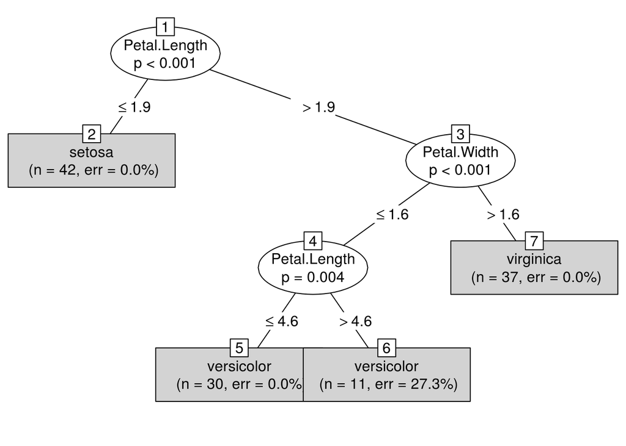

```r
tree.iris <- ctree(Species~., data = iris.main)
plot(tree.iris, type = "simple")
```

Для представления результатов мы часто будем использовать пакет `caret` https://topepo.github.io/caret/index.html. Это пакет-обертка – дает возможность одинакового доступа к функциям, реализующим разные методы машинного обучения: названия методов, позволяющих посчитать, например, матрицу совпадений (ниже) или предсказать новые результаты по уже построенной модели, могут отличаться от разработчика к разработчику. `caret` позволяет не задумываться об этом и использовать одни названия для однотипных действий.

Результаты на обучающей

```r
library(caret)
rpartPred <- predict(tree.iris, iris.main, type = "response")
confusionMatrix(rpartPred,iris.main$Species)
```

```
## Confusion Matrix and Statistics
##
##             Reference
## Prediction   setosa versicolor virginica
##   setosa         42          0         0
##   versicolor      0         38         3
##   virginica       0          0        37
##
## Overall Statistics
##
##                Accuracy : 0.975
##                  95% CI : (0.9287, 0.9948)
##     No Information Rate : 0.35
##     P-Value [Acc > NIR] : < 2.2e-16
##
##                   Kappa : 0.9625
##  Mcnemar's Test P-Value : NA
##
## Statistics by Class:
##
##                      Class: setosa Class: versicolor Class: virginica
## Sensitivity                   1.00            1.0000           0.9250
## Specificity                   1.00            0.9634           1.0000
## Pos Pred Value                1.00            0.9268           1.0000
## Neg Pred Value                1.00            1.0000           0.9639
## Prevalence                    0.35            0.3167           0.3333
## Detection Rate                0.35            0.3167           0.3083
## Detection Prevalence          0.35            0.3417           0.3083
## Balanced Accuracy             1.00            0.9817           0.9625
```

```r
cm<-confusionMatrix(rpartPred,iris.main$Species)
cm$overall
```

```
##       Accuracy          Kappa  AccuracyLower  AccuracyUpper   AccuracyNull
##   9.750000e-01   9.624922e-01   9.286768e-01   9.948144e-01   3.500000e-01
## AccuracyPValue  McnemarPValue
##   3.540940e-49            NaN
```

- Как устроена матрица соответствий (confusion matrix)
- Хорошая это точность или нет?

Результаты на тестовой выборке

```r
rpartPred <- predict(tree.iris, iris.test, type = "response")
confusionMatrix(rpartPred, iris.test$Species)
```

```
## Confusion Matrix and Statistics
##
##             Reference
## Prediction   setosa versicolor virginica
##   setosa          8          0         0
##   versicolor      0         10         1
##   virginica       0          2         9
##
## Overall Statistics
##
##                Accuracy : 0.9
##                  95% CI : (0.7347, 0.9789)
##     No Information Rate : 0.4
##     P-Value [Acc > NIR] : 1.698e-08
##
##                   Kappa : 0.8485
##  Mcnemar's Test P-Value : NA
##
## Statistics by Class:
##
##                      Class: setosa Class: versicolor Class: virginica
## Sensitivity                 1.0000            0.8333           0.9000
## Specificity                 1.0000            0.9444           0.9000
## Pos Pred Value              1.0000            0.9091           0.8182
## Neg Pred Value              1.0000            0.8947           0.9474
## Prevalence                  0.2667            0.4000           0.3333
## Detection Rate              0.2667            0.3333           0.3000
## Detection Prevalence        0.2667            0.3667           0.3667
## Balanced Accuracy           1.0000            0.8889           0.9000
```

- Сравните с результатом на обучающей. Что можете сказать?

### Рак груди

Разбиение на тестовую и обучающую (уже сделали чуть раньше)

```r
set.seed(100) #You shoud put here your own number
br.test.ind = sample(seq_len(nrow(BreastCancer)), size = nrow(BreastCancer)*0.2)
breast.test = BreastCancer[br.test.ind,]
breast.main = BreastCancer[-br.test.ind,]
```

Построение модели

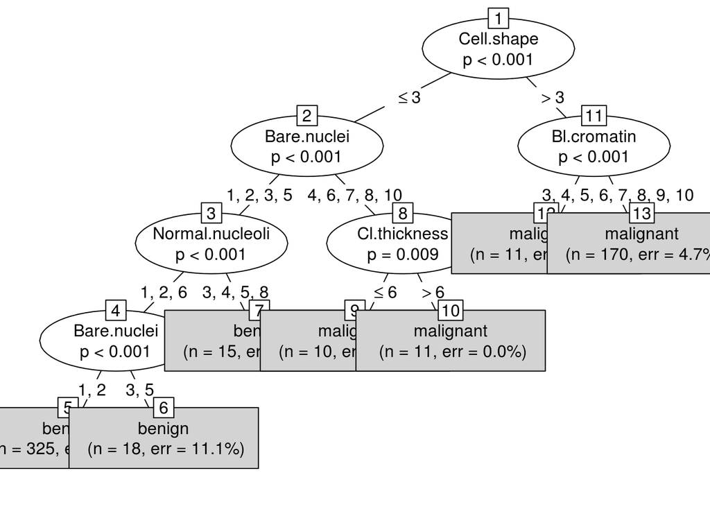

```r
tree.breast <- ctree(Class~., data = breast.main)
plot(tree.breast, type = "simple")
```

Метрики (malignant = злокачественная, benign = доброкачественная)

```r
breastPred <- predict(tree.breast, breast.main, type = "response")
confusionMatrix(breastPred,breast.main$Class)
```

```
## Confusion Matrix and Statistics
##
##            Reference
## Prediction  benign malignant
##   benign       350         8
##   malignant     17       185
##
##                Accuracy : 0.9554
##                  95% CI : (0.9348, 0.9709)
##     No Information Rate : 0.6554
##     P-Value [Acc > NIR] : <2e-16
##
##                   Kappa : 0.9023
##  Mcnemar's Test P-Value : 0.1096
##
##             Sensitivity : 0.9537
##             Specificity : 0.9585
##          Pos Pred Value : 0.9777
##          Neg Pred Value : 0.9158
##              Prevalence : 0.6554
##          Detection Rate : 0.6250
##    Detection Prevalence : 0.6393
##       Balanced Accuracy : 0.9561
##
##        'Positive' Class : benign
##
```

## Еще раз про метрики

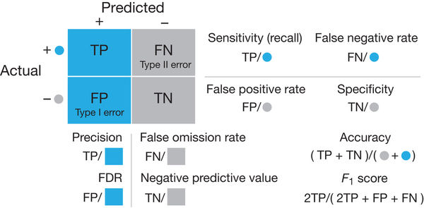

Посчитаем Accuracy, Recall = Sensitivity, Precision = Positive Predictive Value

Результаты на тестовой выборке

```r
breastPred <- predict(tree.breast, breast.test, type = "response")
confusionMatrix(breastPred,breast.test$Class)
```

```
## Confusion Matrix and Statistics
##
##            Reference
## Prediction  benign malignant
##   benign        78         1
##   malignant     13        47
##
##                Accuracy : 0.8993
##                  95% CI : (0.8368, 0.9438)
##     No Information Rate : 0.6547
##     P-Value [Acc > NIR] : 2.551e-11
##
##                   Kappa : 0.7897
##  Mcnemar's Test P-Value : 0.003283
##
##             Sensitivity : 0.8571
##             Specificity : 0.9792
##          Pos Pred Value : 0.9873
##          Neg Pred Value : 0.7833
##              Prevalence : 0.6547
##          Detection Rate : 0.5612
##    Detection Prevalence : 0.5683
##       Balanced Accuracy : 0.9182
##
##        'Positive' Class : benign
##
```

**Ваша очередь:**

Постройте модели для указанных ниже задач. Не забудьте разделить на тестовую и обучающую выбоорки и интерпретировать результаты

### 3. Детские кресла

Уже рассмотренные в прошлом году данные про продажи детских автомобильных кресел. Задача: предсказать уровень продаж. Т.к. задача классификации предполагает, что целевая переменная (в нашем случае – продажи Sales), должна быть категориальной, то изменим немного наши данные – разделим их на высокие и низкие.

```r
library(ISLR)
library(dplyr)
carseats <- ISLR::Carseats
сarseats <- carseats %>%
  mutate(High = ifelse(Sales <= 8, "No", "Yes")) %>%
  dplyr::select(-Sales)
```

### 4. Виды стекла (Glass Identification Database)

Задача: по указанным параметрам (см. справку) предсказать, к какому классу относится стекло.

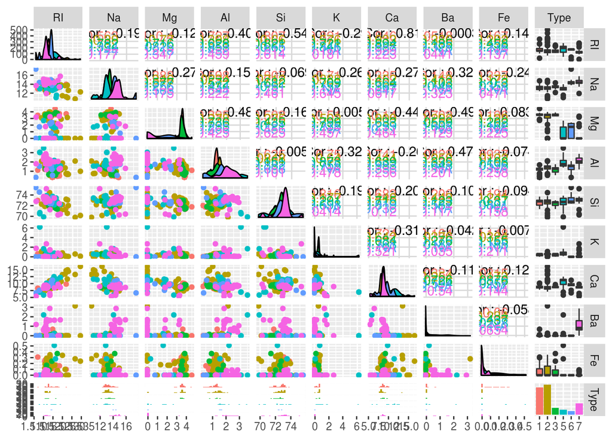

```r
library(mlbench)
data(Glass)
ggpairs(Glass, mapping = aes(color = Type))
```